# xv20220329_FA_SCC_mutations_analysis

x.vergara

2022-06-24

```r
knitr::opts_chunk$set(root.dir = '/DATA/home/x.vergara/XV_P3_ChromDSBScreen/xv_CRISPR_screen_figures/rmarkdown/xv20210920_paper_scripts/short_version/knit_html/')

StartTime <-Sys.time()
library(knitr)

# 8-digit Date tag:
Date <- substr(gsub("-","",Sys.time()),1,8)

#Change in.dir accordingly
in.dir <- "/DATA/home/x.vergara/XV_P3_ChromDSBScreen/xv_CRISPR_screen_figures/"

#Check if output contain datetag
saveRDS_proof <- function(object, file) {
  if (grepl(Date, file) == T) {
    saveRDS(object, file)
  }
  else {
    print("Incorrect datetag!")
  }
}
```

## Libraries:

```r
library(readxl)
library(tidyverse)
library(GenomicRanges)
library(rtracklayer)
```

## Import data

#Curate data tables: What are the features that I am interested (only select deletions)

```r
#Select only deletions (in all four files)
FA_mutation_del_dt <- FA_mutation_dt %>% filter(svclass == "deletion")
sporadic_mutation_del_dt <- sporadic_mutation_dt %>% filter(svclass == "deletion" & grepl("Neg", sample))
BRCA2_mutation_del_dt <- BRCA2_mutation_dt %>% filter(svclass == "deletion")
BRCA1_mutation_del_dt <- BRCA1_mutation_dt %>% filter(svclass == "deletion")
```

#Data table select columns I will use in the analysis

```r
#select data table (select only useful columns)
FA_mutation_del_sel_dt <- FA_mutation_del_dt %>% select(chr1 = '# chr1', start1, end1, strand1 = strand1...9, chr2, start2, end2,strand2 = strand2...10, id = 'id/name', svclass,non_t = `non-template`,MH = `micro-homology`, sample)
sporadic_mutation_del_sel_dt <- sporadic_mutation_del_dt %>% select(chr1 = '# chr1', start1, end1, strand1 = strand1...9, chr2, start2, end2,strand2 = strand2...10, id = 'id/name', svclass,non_t = `non-template`,MH = `micro-homology`, sample)
BRCA2_mutation_del_sel_dt <- BRCA2_mutation_del_dt %>% select(chr1 = '# chr1', start1, end1, strand1 = strand1...9, chr2, start2, end2,strand2 = strand2...10, id = 'id/name', svclass,non_t = `non-template`,MH = `micro-homology`, sample)
BRCA1_mutation_del_sel_dt <- BRCA1_mutation_del_dt %>% select(chr1 = '# chr1', start1, end1, strand1 = strand1...9, chr2, start2, end2,strand2 = strand2...10, id = 'id/name', svclass,non_t = `non-template`,MH = `micro-homology`, sample)

#Combine dataframes together
all_tumour_deletions <- FA_mutation_del_sel_dt %>% filter(sample %in% FANCA_mut_tumours) %>% bind_rows(sporadic_mutation_del_sel_dt) %>% bind_rows(BRCA2_mutation_del_sel_dt) %>% bind_rows(BRCA1_mutation_del_sel_dt)
```

#Import LADs data

```r
setwd(in.dir)
# LAD domains
LAD_atlas <- as.data.frame(read.table("import/xv20220329_LAD_atlas_OSF.bed.gz",header = FALSE, sep="\t",stringsAsFactors=FALSE, quote=""))
colnames(LAD_atlas) <- c("chr","start","end","length","strand","LAD_class")

#LAD_length plot control
LAD_length_tibble <- LAD_atlas %>% mutate(LAD_length = end - start)
```

#Data create MH_length data_table where I extract only MH mutations

```r
#Create some useful variables
all_tumour_deletions_clasified <- all_tumour_deletions %>%
  mutate(del_length = start2-start1, #Deletion length
         del_class = case_when(grepl("[A-Z]", MH) ~ "MH",grepl("[A-Z]", non_t) ~ "non_t", T ~ "none"), #Deletion class: microhomology or non-templated
         type = case_when(grepl("BRCA2", sample) ~ "BRCA2mut", grepl("BRCA1", sample) ~ "BRCA1mut",grepl("HNSCC", sample) ~ "spo", grepl("F",sample) ~ "FA")) #Tumour background

#Summary table for tumours
mutations.summarized <- all_tumour_deletions_clasified %>% dplyr::group_by(del_class, type) %>% dplyr::summarise(FA_count = n())
```

#Check trend across all tumours: total amount of mutations It fits with what the screen predicts - BRCA2 (*) = favors NHEJ/ represses MMEJ in euchromatin - BRCA1 (ns) = favors MMEJ in triple_het - FANCA (ns = 0.07) = favors MMEJ in polycomb Expected outcomes: - BRCA2mut = Relatively more MH mutations in euchromatin (ciLADs) vs cLADs compared to sporadic tumours - BRCA1mut = Relatively less MH mutation in LADs vs iLADs compared compared to sporadic tumours - FANCAmut = Relatively less MH mutations in H3K27me3 vs iH3K27me3 compared to sporadic tumours Measurement = log2 fc Domain/iDomain - BRCA2mut = Down - BRCA1mut = Down - FANCAmut = Down

```r
#Prepare the data table for export
mutation_location_export <- all_tumour_deletions_clasified %>% mutate(mut_id = paste(sample, id, sep = "_"), chr = paste0("chr", chr1)) %>% select(chr, start = "start1", end = "start2", strand = "strand1" ,mut_id, del_class, del_length)
mutation_location_GR <- makeGRangesFromDataFrame(mutation_location_export, keep.extra.columns = T)

#Crate ranges with LADS
LAD_atlas_ranges <- makeGRangesFromDataFrame(LAD_atlas, keep.extra.columns = T)
LAD_overlaps <- findOverlaps(LAD_atlas_ranges,mutation_location_GR)
LAD_overlaps_dt <- tibble(mutation_location_export[subjectHits(LAD_overlaps),], LAD_status =  LAD_atlas[queryHits(LAD_overlaps),6])

#Put both together
mut_data_LADs <- LAD_overlaps_dt %>% mutate(type = case_when(grepl("BRCA2", mut_id) ~ "BRCA2mut", grepl("BRCA1", mut_id) ~ "BRCA1mut",grepl("HNSCC", mut_id) ~ "spo", grepl("F",mut_id) ~ "FA"))  %>% separate(mut_id, sep = "_(?=[1-9])", into = c("sample","id"))
mut_data_LADs$id  <- as.double(mut_data_LADs$id)

# Some deletions are very big and span over LADs and iLADs (filter only deletions that occur within the same iLAD or LAD)
LAD_counts <- mut_data_LADs %>% dplyr::group_by(sample, id) %>% dplyr::summarize(count = n())
single_LADs_iLADs <-LAD_counts %>% filter(count == 1) %>% select(sample, id)

#Filter only FANCA tumours
sim.chrom.status.cd <- mut_data_LADs %>% right_join(single_LADs_iLADs) %>% left_join(FA_tumour_type_cg %>% distinct()) %>% mutate(type_cd = paste(type, CD, sep = "_")) %>% filter(type != "FA" | type_cd == "FA_A")
#Call HPV status of tumors
sim.chrom.status.cd.hpv <- sim.chrom.status.cd %>% rowwise() %>% mutate(HPV = grepl("HPVPos", sample))
```

```r
# Export data
saveRDS_proof(sim.chrom.status.cd.hpv, file = "data/processed_data/xv20220624_SCC_SV_MH_deletions.rds")
```

#All mutations chromatin environment independent

```r
mut_per_tumour <- sim.chrom.status.cd.hpv %>% select(type,sample) %>% distinct() %>% dplyr::group_by(type) %>% dplyr::summarise(tumor_number = n())

# Normalize mutations per sample (normalized to total amount of tumours)
mutations_tumour_norm <- sim.chrom.status.cd.hpv %>% dplyr::group_by(sample,type,del_class) %>% dplyr::summarise(count = n()) %>% ungroup() %>% dplyr::group_by(type,del_class) %>% dplyr::summarise(mean_c = mean(count))
```

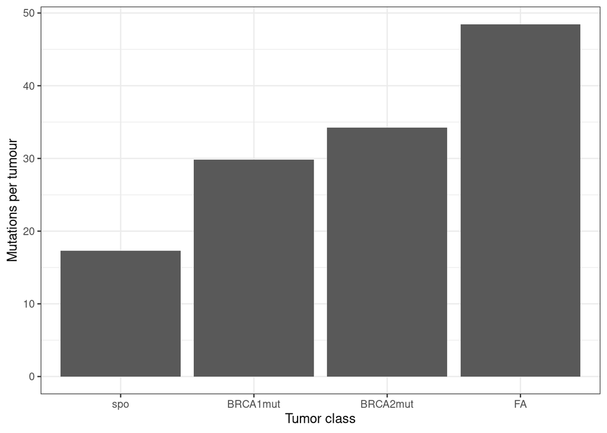

```r
ggplot(mutations_tumour_norm %>% filter(del_class == "MH")) + geom_col(aes(fct_relevel(type, c("spo")),mean_c)) + theme_bw() + ylab("Mutations per tumour") + xlab("Tumor class")
```

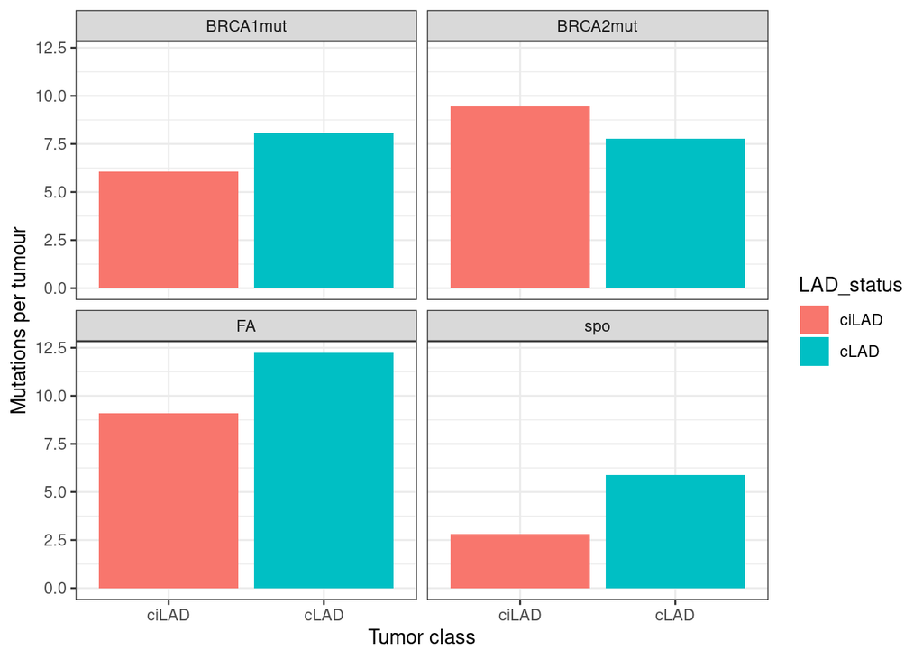

```r
#Plot split by LAD and iLAD
LAD.data.mut <- sim.chrom.status.cd.hpv %>% dplyr::group_by(type,del_class, LAD_status,HPV) %>% dplyr::summarise(count = n()) %>% left_join(mut_per_tumour) %>% rowwise() %>% mutate(mean_c_LAD = count/tumor_number) %>% ungroup()
LAD.data.mut.filtered <- LAD.data.mut %>% filter(LAD_status %in% c("ciLAD","cLAD") & del_class == "MH" & HPV == FALSE)
LAD.data.mut.filtered_del_class <- LAD.data.mut %>% filter(del_class == "MH")

ggplot(LAD.data.mut.filtered) + geom_col(aes(LAD_status, mean_c_LAD, fill = LAD_status)) + theme_bw() + ylab("Mutations per tumour") + xlab("Tumor class") + facet_wrap(~ type)
```